# STAT 184 Final Project: How City Density and Infrastructure Choices Affect Car Safety

**Car dependence and navigating car infrastructure has become an integral part of our lives, for better or for worse. Car accidents are seen as something that is unavoidable, and every driver is told that it will happen to them at one point or another. However, is this mindset something that is causing us to overlook possible safety hazards in our infrastructure? Are there certain things that cause us to drive recklessly? This is what will be explored today.**

**Today I will be using the following library packages:**

```r
library(usmap)
library(ggplot2)
library(maptools)
library(dplyr)
library(geosphere)
library(dbscan)
```

## Part 1: File Access and Exploration

```r
#gzip was used to serialize data for file size constraints
#isolated paths
PATH_TO_CAR_ACCIDENTS = "data/CarAccidents.csv.gz"
PATH_TO_POP_DENSITY = "data/uscities.csv.gz"
```

```r
#read files
ca = gzfile(PATH_TO_CAR_ACCIDENTS,"rt")
CarAccidents = read.csv(ca)

cd = gzfile(PATH_TO_POP_DENSITY, "rt")
USCities = read.csv(cd)
```

**I will now write some code to better visualize the data as-is. We will dig further down and look at relationships later.**

```r
#CarAccidents is too big
CarAccidents <- CarAccidents[sample(nrow(CarAccidents), 200000), ]
head(CarAccidents)
```

|  | X | Severity | Start_Lat | Start_Lng | Description | Number | Street | Side | City | State | Zipcode | Temperature.F. | Wind_Chill.F. | Visibility.mi. | Wind_Speed.mph. | Precipitation.in. | Weather_Condition | Bump | Crossing | Junction | No_Exit | Railway | Roundabout | Station | Stop | Traffic_Calming | Traffic_Signal | Sunrise_Sunset | Civil_Twilight |
| --- | --- | --- | --- | --- | --- | --- | --- | --- | --- | --- | --- | --- | --- | --- | --- | --- | --- | --- | --- | --- | --- | --- | --- | --- | --- | --- | --- | --- | --- |
| 255433 | 2224639 | 2 | 35.49656 | -119.16000 | At Lerdo Hwy - Accident. Hard shoulder blocked. | NA | CA-99 N | R | Bakersfield | CA | 93308 | 56 | 56 | 10 | 7 | 0 | Fair | False | False | False | False | False | False | False | False | False | False | Night | Night |
| 694160 | 1448498 | 2 | 35.61588 | -119.43790 | Accident from McCombs Ave to Hanawalt Ave. | 14868 | Wildwood Rd | R | Wasco | CA | 93280-7502 | 79 | 79 | 10 | 5 | 0 | Fair | False | False | False | False | False | False | False | False | False | False | Night | Night |
| 880796 | 1393115 | 2 | 36.12434 | -86.84702 | Slow traffic on TN-155 from Estes Rd (TN-155) to TN-1/Harding Pike (TN-155) due to accident. | NA | Woodmont Blvd | R | Nashville | TN | 37205 | 42 | 35 | 10 | 14 | 0 | Fair | False | False | False | False | False | False | False | False | False | False | Night | Day |
| 367874 | 2488818 | 2 | 43.40339 | -124.23930 | At 17th St - Accident. | 2234 | Broadway Ave | L | North Bend | OR | 97459-2330 | 61 | 61 | 3 | 7 | 0 | Rain | False | False | False | False | False | False | False | False | False | False | Night | Night |
| 1416059 | 323904 | 2 | 33.29139 | -117.22560 | Incident on MISSION RD near HOUSE 5565 Drive with caution. | 5501 | Mission Rd | R | Bonsall | CA | 92003-3606 | 72 | 72 | 10 | 8 | 0 | Fair | False | False | False | False | False | False | False | False | False | False | Day | Day |
| 767992 | 1047199 | 2 | 30.37174 | -91.08523 | Stationary traffic on LA-427 from Bluebonnet Blvd (Perkins Rd/LA-427) to Highland Rd (Perkins Rd/LA-427) due to accident. | 11556 | Perkins Rd | R | Baton Rouge | LA | 70810-1822 | 63 | 63 | 10 | 5 | 0 | Fair | False | False | False | False | False | False | False | False | False | False | Day | Day |

```r
head(USCities)
```

|  | city | city_ascii | state_id | state_name | county_fips | county_name | lat | lng | population | density | source | military | incorporated | timezone | ranking | zips | id |
| --- | --- | --- | --- | --- | --- | --- | --- | --- | --- | --- | --- | --- | --- | --- | --- | --- | --- |
| 1 | New York | New York | NY | New York | 36081 | Queens | 40.6943 | -73.9249 | 18972871 | 10768.2 | shape | FALSE | TRUE | America/New_York | 1 | 11229 11226 11225 11224 11223 11221 11220 11385 10169 10168 10167 10165 10162 10282 10280 10040 10044 11109 11102 11103 11106 11104 11379 11378 11377 11697 11694 11692 11693 11691 10271 10279 10278 10… | 1840034016 |
| 2 | Los Angeles | Los Angeles | CA | California | 6037 | Los Angeles | 34.1141 | -118.4068 | 12121244 | 3267.6 | shape | FALSE | TRUE | America/Los_Angeles | 1 | 90291 90293 90292 91316 91311 90035 90034 90037 90031 90039 90008 90004 90005 90006 90007 90001 90002 90003 91504 90710 90089 91306 91344 91345 91340 91342 91343 90036 90247 90248 91436 91371 91608 91… | 1840020491 |
| 3 | Chicago | Chicago | IL | Illinois | 17031 | Cook | 41.8375 | -87.6866 | 8595181 | 4576.6 | shape | FALSE | TRUE | America/Chicago | 1 | 60018 60649 60641 60640 60643 60642 60645 60644 60647 60646 60616 60617 60614 60615 60612 60613 60610 60611 60618 60619 60827 60661 60660 60638 60639 60634 60636 60637 60630 60631 60632 60633 60605 60… | 1840000494 |
| 4 | Miami | Miami | FL | Florida | 12086 | Miami-Dade | 25.7840 | -80.2101 | 5711945 | 4945.7 | shape | FALSE | TRUE | America/New_York | 1 | 33128 33129 33125 33126 33127 33149 33144 33145 33142 33139 33138 33137 33136 33135 33134 33133 33132 33131 33130 33150 33101 33109 33111 33151 33222 33231 33233 33238 33255 33299 | 1840015149 |
| 5 | Dallas | Dallas | TX | Texas | 48113 | Dallas | 32.7935 | -96.7667 | 5668165 | 1522.2 | shape | FALSE | TRUE | America/Chicago | 1 | 75287 75098 75234 75254 75251 75252 75253 75032 75238 75232 75233 75230 75231 75236 75237 75235 75089 75088 75087 75247 75244 75249 75248 75051 75223 75210 75211 75212 75214 75215 75216 75217 75218 75… | 1840019440 |
| 6 | Houston | Houston | TX | Texas | 48201 | Harris | 29.7860 | -95.3885 | 5650910 | 1394.6 | shape | FALSE | TRUE | America/Chicago | 1 | 77069 77068 77061 77060 77063 77062 77065 77064 77067 77066 77346 77571 77036 77037 77034 77035 77032 77033 77030 77031 77038 77449 77489 77044 77043 77042 77204 77598 77018 77019 77015 77016 77017 77… | 1840020925 |

**Here is a visualization of population density in the US. If there is some sort of connection between population density and car accidents, we will see them. Note that these two data sources are extremely vast, and we can cut much of it out to focus on more interesting areas once we have a better understanding of the dataset itself.**

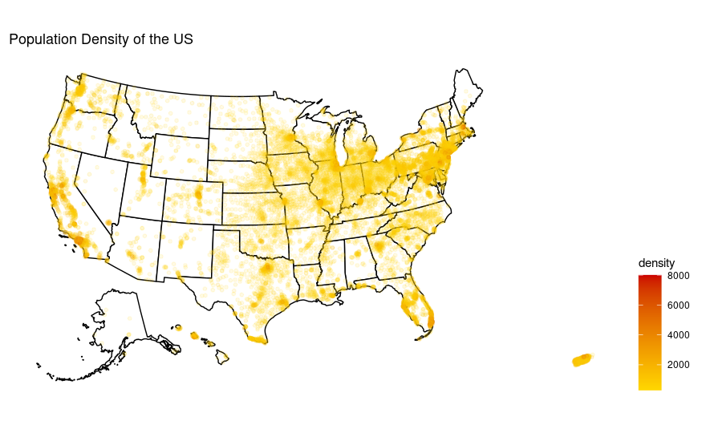

```r
# Viewing US Population Density in a readable way
Density <- USCities %>%
  filter(density > 300) %>%
  select(lng, lat, city, state_id, density)

transformedUSC <- usmap_transform(Density, input_names = c("lng", "lat"))

plot_usmap() +
  geom_point(data = transformedUSC, aes(x = x, y = y, color = density, alpha = density),
             size = 1) +
  scale_color_gradient(low = "#FFD700", high = "#CC0000", limits = c(300, 8000), guide="colourbar") +
  labs(title = "Population Density of the US",
       size = "Density") +
  theme(legend.position = "right") +
  guides(alpha = "none")
```

```r
NA
NA
```

**We can see that the largest population densities can be seen in the Northeast, particularly in the Tri-state area. However, there are pockets of density in areas like Miami, Southern California, San Diego and Seattle.**  
**It is difficult to plot each individual record of 1,500,000 car accidents, so I will take advantage of Density-Based Spatial Clustering of Applications with Noise. this will essentially group records that are nearby one-another, giving us an effective density chart. If the chart looks similar to the population density chart, one may assume that population density plays little to no role in Car Accidents.**

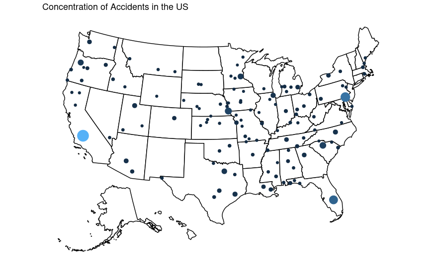

```r
# Count the number of occurrences of each cluster
cluster_counts <- count(cluster_data, cluster)

# Join the counts to the cluster data
cluster_data_with_counts <- left_join(cluster_data, cluster_counts, by = "cluster")

cluster_centers <- cluster_data_with_counts %>%
  group_by(n) %>%
  summarize(x = mean(x),
            y = mean(y))
plot_usmap() +
  geom_point(data = cluster_centers, aes(x = x, y = y, size = n, color = n)) +
  labs(title = "Concentration of Accidents in the US",
       size = "Density") +
  theme(legend.position = "none")
```

[output not shown]

```r
NA
```

## Data Wrangling

```r
DensestCities <- Density %>%
  top_n(200, density)

truncate_coordinates <- function(truncated_table, constraint_table, threshold = 2) {
  lat_diff <- truncated_table$lat - constraint_table$lat
  lon_diff <- truncated_table$lon - constraint_table$lon
  dist <- sqrt(lat_diff^2 + lon_diff^2)
  truncated_data <- truncated_table[dist <= threshold, ]
  return(truncated_data)
}

densest <- data.frame(lon = DensestCities$lng, lat = DensestCities$lat)
```

```r
TruncatedCarAccidents <- CarAccidents %>%
  rename(lat = Start_Lat, lon = Start_Lng) %>%
  subset(select = -c(Number, Street, Side, Zipcode, Wind_Chill.F., Description)) %>%
  truncate_coordinates(densest, 1)

head(TruncatedCarAccidents)
```

|  | X | Severity | lat | lon | City | State | Temperature.F. | Visibility.mi. | Wind_Speed.mph. | Precipitation.in. | Weather_Condition | Bump | Crossing | Junction | No_Exit | Railway | Roundabout | Station | Stop | Traffic_Calming | Traffic_Signal | Sunrise_Sunset | Civil_Twilight |
| --- | --- | --- | --- | --- | --- | --- | --- | --- | --- | --- | --- | --- | --- | --- | --- | --- | --- | --- | --- | --- | --- | --- | --- |
| 1205923 | 1149541 | 2 | 41.63744 | -74.07831 | Wallkill | NY | 28 | 5 | 9 | 0 | Light Snow | False | False | False | False | False | False | False | False | False | False | Night | Night |
| 1379091 | 1323093 | 2 | 33.67837 | -117.75770 | Irvine | CA | 76 | 10 | 6 | 0 | Partly Cloudy | False | False | False | False | False | False | False | False | False | True | Day | Day |
| 1356502 | 2212509 | 2 | 34.20126 | -118.47360 | Van Nuys | CA | 64 | 10 | 7 | 0 | Partly Cloudy | False | False | False | False | False | False | False | False | False | False | Day | Day |
| 850607 | 1569745 | 2 | 34.04770 | -118.00790 | La Puente | CA | 55 | 10 | 3 | 0 | Fair | False | False | False | False | False | False | False | False | False | False | Night | Night |
| 83129 | 2214212 | 3 | 40.80203 | -73.93021 | New York | NY | 37 | 9 | 8 | 0 | Light Rain | False | False | True | False | False | False | False | False | False | False | Night | Day |
| 1392998 | 637159 | 2 | 34.02594 | -117.77860 | Pomona | CA | 70 | 10 | 10 | NA | Fair | False | False | False | False | False | False | False | False | False | False | Day | Day |

## Data Visualization

**There are many different types of car-related infrastructure. Many can be quite problematic at times, causing more accidents than other types of infrastructure used. Here is a plot that demonstrates the prominence of some pieces of infrastructure in the dataset over others.**

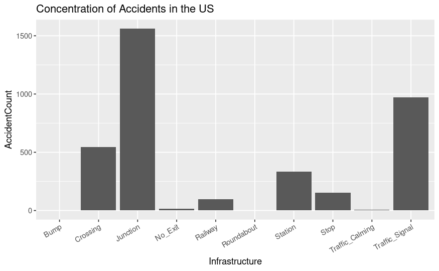

```r
variables <- c("Bump", "Crossing", "Junction", "No_Exit", "Railway", "Roundabout", "Station", "Stop", "Traffic_Calming", "Traffic_Signal")
counts <- c()
for (var in variables)
  {
    count <- sum(TruncatedCarAccidents[[var]] == "True")
    counts <- c(counts, count)
}
InfrastructureCounts <-  data.frame(Infrastructure = variables, AccidentCount = counts)
ggplot(InfrastructureCounts, aes(Infrastructure, AccidentCount))+
  geom_col(position = position_dodge(width=0.5)) +
  theme(axis.text.x = element_text(angle = 30, hjust = 1)) +
  labs(title = "Concentration of Accidents in the US")
```

```r
NA
```

**As you can see, there are virtually no accidents in places with Roundabouts, Bumps and Traffic Calming. These pieces of infrastructure all share the traits that they force the driver to slow down, and they force the driver to pay attention to make sure they’re doing the right thing. Something like a Junction allows for the driver to take turns that are far faster than they would anywhere else without having to be aware of anything around them. Similarly, the traffic signal does not require anyone to be aware of their surroundings; drivers will start moving when the light turns green regardless of what is going on around them.**

### Conclusion

**It seems that there are many things we can do to decrease the number of accidents we see as city planners. Roundabouts pose as a valid replacement for traffic signals in larger areas. Junctions can be built in a way where traffic calming is in play, like the use of ribbed strips of road to encourage drivers to slow down. The accidents that occur in these areas should be considered the fault of the city planner. We cannot change the way that humans act as a whole; rather we must plan our city in a way that works with the natural human mind and tries to mitigate as much danger as possible given those constraints.**